# Proportional Groundfish Redistribution

## 10. Calculate Weekly and Annual Summary Statistics

This step applies the displacement and new PSC calculations.

```r
total.join.master <- sum.stat.timeseries.gf_all3 %>%
  left_join(
    gf_inside_cluster2 %>% select(YEAR, TIME_STEP_KEY, HARVEST_SECTOR, tons_gf_inside_wk),
    by = c("YEAR", "TIME_STEP_KEY", "HARVEST_SECTOR")
  ) %>%
  mutate(
    tons_gf_inside_wk = replace_na(tons_gf_inside_wk, 0),

    # Shared Retrospective Catch Allocation
    gf_catch_new = tons_gf_inside_wk * proportion_outside_wk,

    # Method 1: Volume Track (Real-Time Catch * Real-Time Bycatch-Per-Ton)
    new_PSC_method1 = gf_catch_new * mean_psc_rate_wk,

    # Method 2: Effort Track (Shared Tonnage / 1-Yr Lagged CPUE * Real-Time Bycatch-Per-Minute)
    effort_minutes_needed = ifelse(hist_gf_cpue_seasonal > 0, gf_catch_new / hist_gf_cpue_seasonal, 0),
    new_PSC_method2       = effort_minutes_needed * mean_psc_rate_minutes_wk
  )

# Roll up to the annual summary as standard
ledger_weekly <- total.join.master %>%
  group_by(YEAR, TIME_STEP_KEY, HARVEST_SECTOR) %>%
  summarise(
    new_PSC_m1_wk = sum(new_PSC_method1, na.rm = TRUE),
    new_PSC_m2_wk = sum(new_PSC_method2, na.rm = TRUE),
    .groups = "drop"
  ) %>%
  left_join(
    gf_inside_cluster2 %>% select(YEAR, TIME_STEP_KEY, HARVEST_SECTOR, psc_measure_inside_wk),
    by = c("YEAR", "TIME_STEP_KEY", "HARVEST_SECTOR")
  ) %>%
  mutate(
    psc_measure_inside_wk = replace_na(psc_measure_inside_wk, 0),
    net_change_m1_wk = new_PSC_m1_wk - psc_measure_inside_wk,
    net_change_m2_wk = new_PSC_m2_wk - psc_measure_inside_wk
  )

total.join.plot.annual <- ledger_weekly %>%
  group_by(YEAR) %>%
  summarise(
    est_change_method1 = sum(net_change_m1_wk, na.rm = TRUE),
    est_change_method2 = sum(net_change_m2_wk, na.rm = TRUE),
    .groups = "drop"
  )

total.join = total.join.master
```

## 11. Bootstrap

To provide a measure of uncertainty, we are bootstrapping 1,000 alternative scenarios by randomly shuffling the PSC rates where fishing is redistributed. We calculated a 95% Confidence Interval using the middle 95% of all simulated outcomes (between 2.5th and 97.5th percentiles).

```r
# ==============================================================================
# ## 11. Bootstrap (ROW-PRESERVING COUPLED RESAMPLER)
# ==============================================================================
#| label: spatial-rate-bootstrap

set.seed(345)
n_iterations <- 1000

df_bs_base <- total.join %>%
  dplyr::left_join(
    gf_inside_cluster2 %>% dplyr::select(YEAR, TIME_STEP_KEY, HARVEST_SECTOR, psc_measure_inside_wk),
    by = c("YEAR", "TIME_STEP_KEY", "HARVEST_SECTOR")
  ) %>%
  dplyr::mutate(
    psc_measure_inside_wk = tidyr::replace_na(psc_measure_inside_wk, 0),
    STRATA_KEY = paste0(YEAR, "_", TIME_STEP_KEY, "_", HARVEST_SECTOR) # Include YEAR in strata key!
  )

strata_steps <- unique(df_bs_base$STRATA_KEY)

boot_matrix_m1 <- matrix(NA, nrow = n_iterations, ncol = length(strata_steps))
boot_matrix_m2 <- matrix(NA, nrow = n_iterations, ncol = length(strata_steps))
colnames(boot_matrix_m1) <- strata_steps
colnames(boot_matrix_m2) <- strata_steps

for(i in 1:n_iterations) {
  new_psc_m1_iteration <- numeric(nrow(df_bs_base))
  new_psc_m2_iteration <- numeric(nrow(df_bs_base))

  for(st in strata_steps) {
    st_indices <- which(df_bs_base$STRATA_KEY == st)
    n_records  <- length(st_indices)

    if(n_records > 0) {
      sampled_rows <- sample(st_indices, size = n_records, replace = TRUE)

      # Method 1 Bootstrap Evaluation
      new_psc_m1_iteration[st_indices] <- df_bs_base$gf_catch_new[st_indices] * df_bs_base$mean_psc_rate_wk[sampled_rows]

      # Method 2 Bootstrap Evaluation
      gf_shared_tons <- df_bs_base$gf_catch_new[st_indices]
      cpue_m2        <- df_bs_base$hist_gf_cpue_seasonal[sampled_rows]
      rates_m2       <- df_bs_base$mean_psc_rate_minutes_wk[sampled_rows]

      mins_needed <- ifelse(cpue_m2 > 0, gf_shared_tons / cpue_m2, 0)
      new_psc_m2_iteration[st_indices] <- mins_needed * tidyr::replace_na(rates_m2, 0)
    }
  }

  iter_summary <- df_bs_base %>%
    dplyr::mutate(boot_m1 = new_psc_m1_iteration, boot_m2 = new_psc_m2_iteration) %>%
    dplyr::group_by(YEAR, TIME_STEP_KEY, HARVEST_SECTOR, STRATA_KEY) %>%
    dplyr::summarise(
      sim_outside_m1 = sum(boot_m1, na.rm = TRUE),
      sim_outside_m2 = sum(boot_m2, na.rm = TRUE),
      .groups = "drop"
    ) %>%
    # INCLUDE YEAR IN THIS JOIN TO AVOID MULTI-YEAR MANY-TO-MANY DUPLICATION
    dplyr::left_join(
      gf_inside_cluster2 %>% dplyr::select(YEAR, TIME_STEP_KEY, HARVEST_SECTOR, psc_measure_inside_wk),
      by = c("YEAR", "TIME_STEP_KEY", "HARVEST_SECTOR")
    ) %>%
    dplyr::mutate(
      psc_measure_inside_wk = tidyr::replace_na(psc_measure_inside_wk, 0),
      net_change_m1 = sim_outside_m1 - psc_measure_inside_wk,
      net_change_m2 = sim_outside_m2 - psc_measure_inside_wk
    )

  for(j in seq_along(strata_steps)) {
    match_idx <- which(iter_summary$STRATA_KEY == strata_steps[j])
    if(length(match_idx) == 1) { # Strictly 1 match per unique stratum
      boot_matrix_m1[i, j] <- iter_summary$net_change_m1[match_idx]
      boot_matrix_m2[i, j] <- iter_summary$net_change_m2[match_idx]
    }
  }
}

# Long transformations
boot_long_m1 <- as.data.frame(boot_matrix_m1) %>% dplyr::mutate(iteration = 1:n()) %>%
  tidyr::pivot_longer(-iteration, names_to = "STRATA_KEY", values_to = "net_change")

boot_long_m2 <- as.data.frame(boot_matrix_m2) %>% dplyr::mutate(iteration = 1:n()) %>%
  tidyr::pivot_longer(-iteration, names_to = "STRATA_KEY", values_to = "net_change")

strata_year_map <- df_bs_base %>% dplyr::select(STRATA_KEY, YEAR) %>% dplyr::distinct()

boot_annual_m1 <- boot_long_m1 %>% dplyr::left_join(strata_year_map, by = "STRATA_KEY") %>%
  dplyr::group_by(iteration, YEAR) %>% dplyr::summarise(annual_change = sum(net_change, na.rm = TRUE), .groups = "drop")

boot_annual_m2 <- boot_long_m2 %>% dplyr::left_join(strata_year_map, by = "STRATA_KEY") %>%
  dplyr::group_by(iteration, YEAR) %>% dplyr::summarise(annual_change = sum(net_change, na.rm = TRUE), .groups = "drop")

boot_m1_ci <- boot_annual_m1 %>% dplyr::group_by(YEAR) %>%
  dplyr::summarise(lower_change_m1 = quantile(annual_change, 0.025, na.rm = TRUE),
                   upper_change_m1 = quantile(annual_change, 0.975, na.rm = TRUE), .groups = "drop")

boot_m2_ci <- boot_annual_m2 %>% dplyr::group_by(YEAR) %>%
  dplyr::summarise(lower_change_m2 = quantile(annual_change, 0.025, na.rm = TRUE),
                   upper_change_m2 = quantile(annual_change, 0.975, na.rm = TRUE), .groups = "drop")

boot_annual_ci <- dplyr::left_join(boot_m1_ci, boot_m2_ci, by = "YEAR")
```

## 12. Evaluate Impacts

Compares the estimated PSC change to the observed PSC (status quo) each year. For this example, summarized by year.

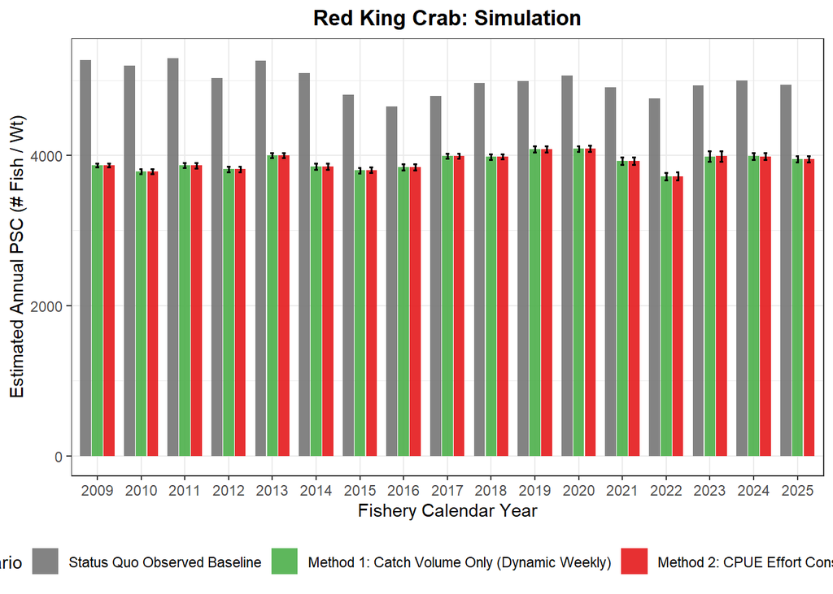

```r
# ==============================================================================
# ## 12. Evaluate Impacts
# ==============================================================================
#| label: fig-status-quo
#| fig-width: 12
#| fig-height: 6

# 1. Clean parameter labels to avoid any trailing workspace text mismatches
clean_spp <- trimws(toupper(params$psc_spp))
spp_title_fixed <- case_when(
  clean_spp == "OTCR" ~ "Snow Crab",
  clean_spp == "BTCR" ~ "Tanner Crab",
  clean_spp == "RKCR" ~ "Red King Crab",
  clean_spp == "HERR" ~ "Herring",
  TRUE                ~ "Groundfish Species"
)

# Parse selected method from params (defaults to "both" if missing)
selected_method <- if (!is.null(params$method)) trimws(tolower(params$method)) else "both"

# 2. Join estimated changes with status quo numbers using the timeline ledger tracking method
total.join.plot.annual2 <- dplyr::left_join(all_psc_status_quo_annual, total.join.plot.annual, by = c("YEAR"))
total.join.plot.annual2$est_change_method1[is.na(total.join.plot.annual2$est_change_method1)] <- 0
total.join.plot.annual2$est_change_method2[is.na(total.join.plot.annual2$est_change_method2)] <- 0

total.join.plot.annual2$net_new_PSC_m1 <- total.join.plot.annual2$sum_psc_status_quo + total.join.plot.annual2$est_change_method1
total.join.plot.annual2$net_new_PSC_m2 <- total.join.plot.annual2$sum_psc_status_quo + total.join.plot.annual2$est_change_method2
total.join.plot.annual2$LABEL          <- paste0("SPECIES")

colnames(total.join.plot.annual2) <- c("YEAR", "psc_statusquo", "psc_change_m1", "psc_change_m2", "net_new_PSC_m1", "net_new_PSC_m2", "LABEL")

# 3. STEP 1: Re-center bootstrap variance directly around the deterministic model means
total.join.plot.annual2 <- total.join.plot.annual2 %>%
  dplyr::left_join(boot_annual_ci, by = "YEAR") %>%
  dplyr::mutate(
    # Method 1 Relative Transformation
    boot_median_m1 = (lower_change_m1 + upper_change_m1) / 2,
    boot_ymin_m1   = net_new_PSC_m1 + (lower_change_m1 - boot_median_m1),
    boot_ymax_m1   = net_new_PSC_m1 + (upper_change_m1 - boot_median_m1),

    # Method 2 Relative Transformation
    boot_median_m2 = (lower_change_m2 + upper_change_m2) / 2,
    boot_ymin_m2   = net_new_PSC_m2 + (lower_change_m2 - boot_median_m2),
    boot_ymax_m2   = net_new_PSC_m2 + (upper_change_m2 - boot_median_m2)
  )

# 4. STEP 2: Pivot long format for clustered bar chart layout
total.join.plot.annual3 <- total.join.plot.annual2 %>% tidyr::pivot_longer(
  cols = c("psc_statusquo", "net_new_PSC_m1", "net_new_PSC_m2"),
  names_to = "psc_type",
  values_to = "psc_amount",
  values_drop_na = TRUE
)

# 5. STEP 3: Isolate upper/lower boundaries based on row categories
total.join.plot.annual3 <- total.join.plot.annual3 %>%
  dplyr::mutate(
    ymin = case_when(
      psc_type == "net_new_PSC_m1" ~ boot_ymin_m1,
      psc_type == "net_new_PSC_m2" ~ boot_ymin_m2,
      TRUE                         ~ NA_real_  # Leaves status quo clean
    ),
    ymax = case_when(
      psc_type == "net_new_PSC_m1" ~ boot_ymax_m1,
      psc_type == "net_new_PSC_m2" ~ boot_ymax_m2,
      TRUE                         ~ NA_real_  # Leaves status quo clean
    )
  )

# 6. DYNAMIC FILTERING & FACTOR MAPPING BASED ON params$method
if (selected_method == "m1") {
  total.join.plot.annual3 <- total.join.plot.annual3 %>%
    dplyr::filter(psc_type %in% c("psc_statusquo", "net_new_PSC_m1"))

  method_levels <- c("psc_statusquo", "net_new_PSC_m1")
  fill_values   <- c("psc_statusquo" = "#757575", "net_new_PSC_m1" = "#4daf4a")
  fill_labels   <- c("Status Quo Observed Baseline", "Method 1: Catch Volume Only (Dynamic Weekly)")

} else if (selected_method == "m2") {
  total.join.plot.annual3 <- total.join.plot.annual3 %>%
    dplyr::filter(psc_type %in% c("psc_statusquo", "net_new_PSC_m2"))

  method_levels <- c("psc_statusquo", "net_new_PSC_m2")
  fill_values   <- c("psc_statusquo" = "#757575", "net_new_PSC_m2" = "#e41a1c")
  fill_labels   <- c("Status Quo Observed Baseline", "Method 2: CPUE Effort Constrained (Seasonal Baseline)")

} else { # "both" or default
  method_levels <- c("psc_statusquo", "net_new_PSC_m1", "net_new_PSC_m2")
  fill_values   <- c("psc_statusquo" = "#757575", "net_new_PSC_m1" = "#4daf4a", "net_new_PSC_m2" = "#e41a1c")
  fill_labels   <- c(
    "Status Quo Observed Baseline",
    "Method 1: Catch Volume Only (Dynamic Weekly)",
    "Method 2: CPUE Effort Constrained (Seasonal Baseline)"
  )
}

# Enforce explicit factorization order
total.join.plot.annual3$psc_type <- factor(
  total.join.plot.annual3$psc_type,
  levels = method_levels
)

# 7. STEP 4: Render plot using dynamic matching values
ggplot(total.join.plot.annual3, aes(x = factor(YEAR), y = psc_amount, fill = psc_type)) +
  ggtitle(paste0(spp_title_fixed, ": ", title_name)) +
  geom_bar(stat = "identity", position = position_dodge(width = 0.8), width = 0.75, alpha = 0.9) +
  geom_errorbar(
    aes(ymin = ymin, ymax = ymax, group = psc_type),
    position = position_dodge(width = 0.8),
    width = 0.25,
    color = "black",
    linewidth = 0.7,
    na.rm = TRUE
  ) +
  theme_bw() +
  labs(x = "Fishery Calendar Year", y = "Estimated Annual PSC (# Fish / Wt)") +
  scale_fill_manual(
    values = fill_values,
    labels = fill_labels,
    name   = "Closure Scenario"
  ) +
  theme(
    plot.title = element_text(face = "bold", size = 13, hjust = 0.5),
    legend.position = "bottom"
  )
```